# COSC-523: Project 01: Image Augmentations with Python

**Daniel Carter**

[Notebook Link](https://colab.research.google.com/drive/1SDQObC2QpfYG3bjRKmLiuVxpOvjDpVaC#scrollTo=1HW_tpnTHbiQ)

## Getting Started

Follow the instructions below to copy this notebook and to perform some initial setup.

1. Copy this notebook by selecting `File > Save a copy in Drive`.
2. A new window should open for the copied notebook. Move the new notebook to your course folder in Google Drive by selecting `File > Move` and then selecting the desired folder.
3. Update the name of the notebook by removing "Copy of" and replacing "Username" with your actual username.
4. Update the first cell in the notebook by specifying your course number (423 or 523) and by replacing "**Student Name**" with your actual name.
5. Do not edit the line that says `PLACEHOLDER_FOR_NOTEBOOK_LINK`. This will be used by the [Notebook Renderer](https://colab.research.google.com/drive/1CJTipys46ldZxJFwnt7XbdjQUfkmoXeU?usp=sharing) tool to insert a link to your Colab notebook.
6. Enable link sharing for your notebook.

# Project Goal

In this project you will learn how to implement some image pre-processing methods and apply them on a cancerous image.

- These steps will be based on the pre-processing techniques mentioned in the pdf named "Project 1 article". This pdf is a research paper published by Dr. Akanksha Maurya and is titled "A deep learning approach to detect blood vessels".
- This project will expect you to complete one of the pre-processing steps in this research paper. The details are explained below. Please download all the files and the links mentioned.
- File descriptions:
- Project Goal.png: Shows what our original image is and what is the output we desire.
- Vessel1.png: is the image we will use in this project
- Project 1 article.pdf is Dr Maurya'a reseacrh paper. You don't need to bother with the whole paper for now, but the next file that is taken from section 2.2
- Project 1 focus.png: is the snip of the portion from the paper that you will implement in this project

# Task 1: Creating multiple augmentations of an image

Instructions:

- Download the vessels1.png image
- The text in in section 2.2 says: We performed these augmentations:  
  Geometric augmentations: random rotation, horizontal flip, and vertical flip.
- Write a function in Python that accepts an image and it produces 5 different images of the original with the 5 versions being:
- a random rotation of the image (the rotation angle should be picked at random)
- a horizontal flip version
- a vertical flip version
- a random zoomed in version
- a random cropped version

Call this function on vessels1.png and display the original image with the 5 augmented verison all in one row and also save those images. All the images displayed should have labels on which augmentations they are. Make sure all augmented image sizes are resized to square dimension.

```python
import cv2
import numpy as np
import matplotlib.pyplot as plt

#Create a function that accepts an image
def preprocess_image(image):
  #Random rotation of the image
  angle = np.random.randint(0, 360)
  rows, cols = image.shape[:2]
  M = cv2.getRotationMatrix2D((cols/2, rows/2), angle, 1)
  rotated_image = cv2.warpAffine(image, M, (cols, rows))
  #horizontal flip of original img
  horizontal_flip = cv2.flip(image, 1)
  #vertical flip of original img
  vertical_flip = cv2.flip(image, 0)
  #random zoomed in version of original img
  zoom_factor = np.random.uniform(0.5, 2.0)
  zoomed_image = cv2.resize(image, None, fx=zoom_factor, fy=zoom_factor)
  #random cropped version
  crop_size = np.random.randint(50, 100)
  x = np.random.randint(0, image.shape[1] - crop_size)
  y = np.random.randint(0, image.shape[0] - crop_size)
  cropped_image = image[y:y+crop_size, x:x+crop_size]
  #return all the images
  return rotated_image, horizontal_flip, vertical_flip, zoomed_image, cropped_image
#Load in vessl1 png and perform function on it
vessel_image = cv2.imread('Vessel1.png')
rotated_image, horizontal_flip, vertical_flip, zoomed_image, cropped_image = preprocess_image(vessel_image)
```

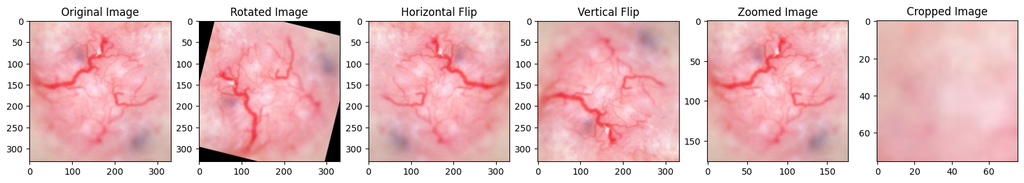

```python
#Plot original image and the five returned from the function
fig, axs = plt.subplots(1, 6, figsize=(20, 20))
axs[0].imshow(cv2.cvtColor(vessel_image, cv2.COLOR_BGR2RGB))
axs[0].set_title('Original Image')
axs[1].imshow(cv2.cvtColor(rotated_image, cv2.COLOR_BGR2RGB))
axs[1].set_title('Rotated Image')
axs[2].imshow(cv2.cvtColor(horizontal_flip, cv2.COLOR_BGR2RGB))
axs[2].set_title('Horizontal Flip')
axs[3].imshow(cv2.cvtColor(vertical_flip, cv2.COLOR_BGR2RGB))
axs[3].set_title('Vertical Flip')
axs[4].imshow(cv2.cvtColor(zoomed_image, cv2.COLOR_BGR2RGB))
axs[4].set_title('Zoomed Image')
axs[5].imshow(cv2.cvtColor(cropped_image, cv2.COLOR_BGR2RGB))
axs[5].set_title('Cropped Image')
plt.show()
```

# Task 2: Histogram Stretching

Instructions:

- The second part of Project 1 focus.png talks about histogram stretching. Explain what histogram stretching is (it is not histogram equalization, you can use google to find the differences)
- Write a function that performs histogram stretching on an input image and please use links shared for help. Please make sure you apply it on all color channels.
- Call the function with vessels1.png and display the original image and the histogram stretched image
- Save the histogram stretched image and call it HS_vessel.

# Histogram Stretching

## From my research, histogram stretching is a form of contrast enhancement with the overall goal of improving the clarity of an image.

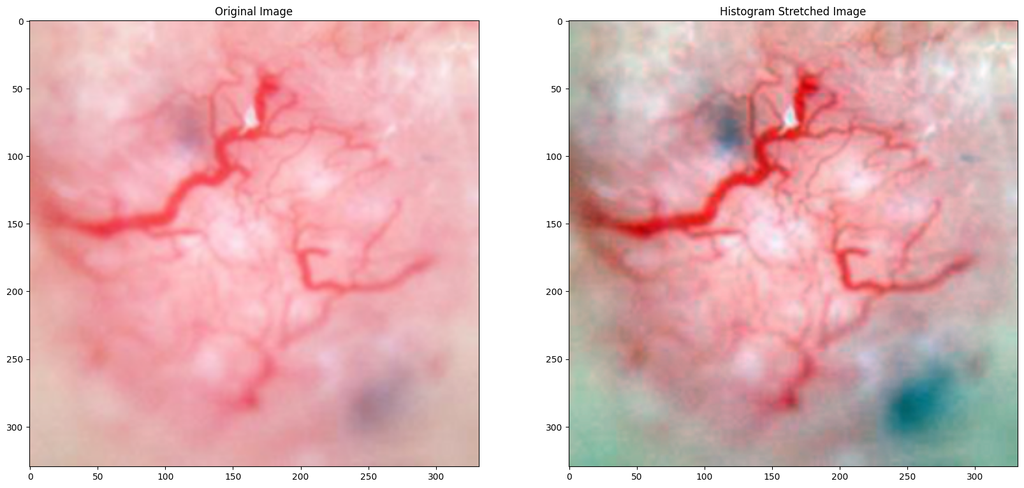

```python
#Need to create a function that performs histogram stretching
def histogram_stretching(image):
  #Convert image from BGR to RGB
  image = cv2.cvtColor(image, cv2.COLOR_BGR2RGB)
  #split up the channels
  r, g, b = cv2.split(image)
  def stretch_channel(channel):
    #find the minimum and maximum values of the channel
    min_val = np.min(channel)
    max_val = np.max(channel)
    if max_val == min_val:
      return channel
    #stretch the channel
    stretched = ((channel - min_val) / (max_val - min_val)) * 255
    return np.uint8(stretched)
  r_streched = stretch_channel(r)
  g_streched = stretch_channel(g)
  b_streched = stretch_channel(b)
  stretched_image = cv2.merge((r_streched, g_streched, b_streched))
  #convert back to BGR
  stretched_image_adjusted = cv2.cvtColor(stretched_image, cv2.COLOR_RGB2BGR)
  #save stretched image
  cv2.imwrite('HS_vessel.png', stretched_image_adjusted)
  #plot original and stretched image
  fig, axs = plt.subplots(1, 2, figsize=(20, 20))
  axs[0].imshow(image)
  axs[0].set_title('Original Image')
  axs[1].imshow(stretched_image)
  axs[1].set_title('Histogram Stretched Image')
  plt.show()
  return stretched_image
#Apply this to vessel img
stretched_image = histogram_stretching(vessel_image)
```

# Task 3: CLAHE

Instructions:

- Now perform Contrast Limited Adaptive Histogram Equalization (CLAHE) to equalize the HS_vessel image. Lots of Python libraries have this inbuilt, you can use OpenCV
- CLAHE is a variant of Adaptive histogram equalization (AHE) which takes care of over-amplification of the contrast. CLAHE operates on small regions in the image, called tiles, rather than the entire image. The neighboring tiles are then combined using bilinear interpolation to remove the artificial boundaries.
- Save this image as HS_CLAHE_vessel
- Display the original image, the HS_vessel and HS_CLAHE_vessel

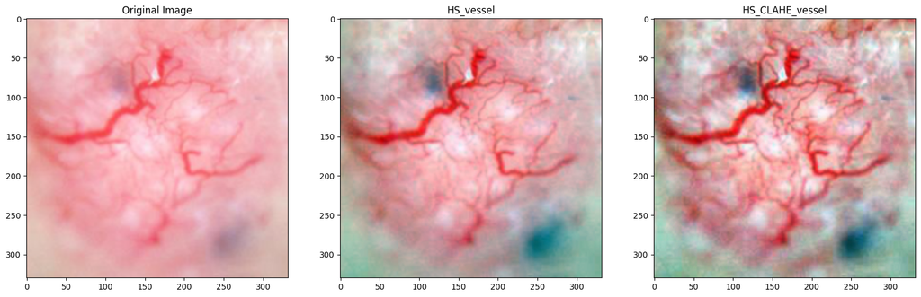

```python
#Create function to perform CLAHE on saved HS_vessel image
def clahe(image):
  #convert image to RGB
  image = cv2.cvtColor(image, cv2.COLOR_BGR2RGB)
  #split up the channels
  r, g, b = cv2.split(image)
  #create clahe object
  clahe = cv2.createCLAHE(clipLimit=2.0, tileGridSize=(8,8))
  #apply clahe to each channel
  r_clahe = clahe.apply(r)
  g_clahe = clahe.apply(g)
  b_clahe = clahe.apply(b)
  #merge the channels
  clahe_image = cv2.merge((r_clahe, g_clahe, b_clahe))
  #convert back to BGR
  clahe_image_adjusted = cv2.cvtColor(clahe_image, cv2.COLOR_RGB2BGR)
  #save the image
  cv2.imwrite('HS_CLAHE_vessel.png', clahe_image_adjusted)
  #plot original, hs_vessel, and hs_clahe image
  original_img = cv2.imread('Vessel1.png')
  original_img = cv2.cvtColor(original_img, cv2.COLOR_BGR2RGB)
  fig, axs = plt.subplots(1, 3, figsize=(20, 20))
  axs[0].imshow(original_img)
  axs[0].set_title('Original Image')
  axs[1].imshow(image)
  axs[1].set_title('HS_vessel')
  axs[2].imshow(clahe_image)
  axs[2].set_title('HS_CLAHE_vessel')
  plt.show()
  return clahe_image
#read in HS_vessel img
stretched_image = cv2.imread('HS_vessel.png')
clahe_image = clahe(stretched_image)
```

# Task 4: RGB Normalization

Instructions:

- Now perform RGB Normalization on the HS_CLAHE_vessel image. Remember, to perform RGB normalization, you normalize each channel and then merge the normalized channels together.
- Save this image as HS_CLAHE_NORM_vessel -Display the original image and HS_CLAHE_NORM_vessel side by side.

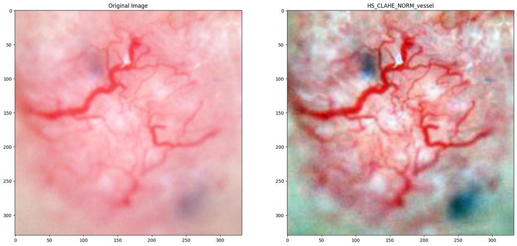

```python
#Create function on RGB Normalization
def rgb_normalization(image):
  #convert image to RGB
  image = cv2.cvtColor(image, cv2.COLOR_BGR2RGB)
  #split up the channels
  r, g, b = cv2.split(image)
  #normalize each
  r_norm = (r - np.min(r)) / (np.max(r) - np.min(r))
  g_norm = (g - np.min(g)) / (np.max(g) - np.min(g))
  b_norm = (b - np.min(b)) / (np.max(b) - np.min(b))
  #merge the channels
  normalized_image = cv2.merge((r_norm, g_norm, b_norm))
  #convert back to uint8
  normalized_image_uint8 = np.uint8(normalized_image * 255)
  #convert back to BGR
  normalized_image_adjusted = cv2.cvtColor(normalized_image_uint8, cv2.COLOR_RGB2BGR)
  #save the image
  cv2.imwrite('HS_CLAHE_NORM_vessel.png', normalized_image_adjusted)
  #plot original image next to normalized
  original_img = cv2.imread('Vessel1.png')
  original_img = cv2.cvtColor(original_img, cv2.COLOR_BGR2RGB)
  fig, axs = plt.subplots(1, 2, figsize=(20, 20))
  axs[0].imshow(original_img)
  axs[0].set_title('Original Image')
  axs[1].imshow(normalized_image)
  axs[1].set_title('HS_CLAHE_NORM_vessel')
  plt.show()
  return normalized_image
#read in HS_CLAHE_vessel img
clahe_image = cv2.imread('HS_CLAHE_vessel.png')
normalized_image = rgb_normalization(clahe_image)
```

# Task 5: Brightness/Contrast Enhancement

Instructions:

- For the last step we will now perform brightness/contrast enhancement on the HS_CLAHE_NORM_vessel image.
- OpenCV provides easy methods to apply different brightness/contrast enhancement techniques. You can use the link for help and try to apply techniques that would produced the output closest to the output image in the project goal.
- Display the original image and the final output image side by side. Save them too. Call the final image, Project 1 final output.

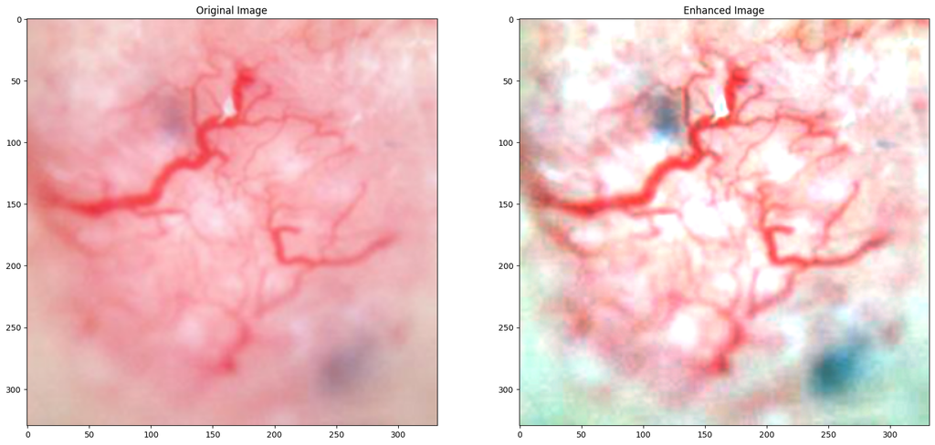

```python
#Define function to adjust brightness and contrast of image
def brightness_contrast_enhancement(image, alpha, beta):
  #convert image to RGB
  image = cv2.cvtColor(image, cv2.COLOR_BGR2RGB)
  #apply brightness/contrast enhancement
  enhanced_image = cv2.convertScaleAbs(image, alpha=alpha, beta=beta)
  #convert back to bgr
  enhanced_image_adjusted = cv2.cvtColor(enhanced_image, cv2.COLOR_RGB2BGR)
  #save the image
  cv2.imwrite('Project_1_final_output.png', enhanced_image_adjusted)
  #plot original image next to enhanced
  original_img = cv2.imread('Vessel1.png')
  original_img = cv2.cvtColor(original_img, cv2.COLOR_BGR2RGB)
  fig, axs = plt.subplots(1, 2, figsize=(20, 20))
  axs[0].imshow(original_img)
  axs[0].set_title('Original Image')
  axs[1].imshow(enhanced_image)
  axs[1].set_title('Enhanced Image')
  plt.show()
  return enhanced_image
#Read in HS_CLAHE_NORM image and run it through the function
normalized_image = cv2.imread('HS_CLAHE_NORM_vessel.png')
enhanced_image = brightness_contrast_enhancement(normalized_image, 1.0, 50)
```

# Submission Instructions

1. Perform a Restart and Run All by clicking **Tools > Restart session and run all**.
2. Copy the link to your notebook by clicking **Share > Copy Link**.
3. Paste the copied link into the `notebook_url` field in the [Notebook Renderer](https://colab.research.google.com/drive/1CJTipys46ldZxJFwnt7XbdjQUfkmoXeU?usp=sharing) tool and then execute the cell to render the notebook.
4. The Notebook Renderer will open up a save file dialog. Save the resulting HTML file yo your local machine.
5. Submit the HTML file to Canvas.